# TLR%_Genetics

SteveYounkin

November 14, 2015

## Analysis Plan

We will analyze SORCS2 genotypes using a robust, R-based reproducible research approach.

We will keep all of our work in one R Markdown document: TLR5_Genetics.Rmd.

To communicate with one another as we build this document, we will use the SORCS2 repository in my github account (https://github.com/StevenGYounkin/TLR5), and we will all use git (GitHub gui) for version control.

All files used or generated by TLR5_Genetics.Rmd will be in this TLR5 repo.

Joseph will take responsiblity for providing whatever help may be needed for each of us to interact effectively with one another on GitHub to produce a final document.

Our goal, which we may or may not achieve, will be to have an analysis in the Rmd file completed by 12/4/15 that is ready to accept additional data from the ADSP dataset for final analysis and publication.

### What each participant needs:

1. RStudio installed
2. GitHub installed
3. Local clone of the repo at https://github.com/StevenGYounkin/TLR5
   - TLR5_Genetics.Rmd, the file we are generating together, is in this repo
     - All files used or generated by TLR5_Genetics.Rmd are in this repo
4. R packages installed
   - dplyr
   - data.table
5. PLINK installed and set up so it can be called by R with system(“plink……”)
6. Perl installed and set up so it can be called by R with system(" “)

### Useful documentation:

1. GitHub
   - https://training.github.com/kit/downloads/github-git-cheat-sheet
2. R Markdown
   - https://www.rstudio.com/wp-content/uploads/2015/02/rmarkdown-cheatsheet.pdf
3. dplyr and tidyr
   - https://www.rstudio.com/wp-content/uploads/2015/02/data-wrangling-cheatsheet.pdf
4. PLINK
   - http://pngu.mgh.harvard.edu/~purcell/plink/

### Responsibility for Specific Analysis Steps:

1. Steve will read in existing well-documented TLR% dataset(s)
2. Steve will provide the initial Rmd file which will have useful “template”
3. Ben and Leonie will develop the Rmd file to meet the goals of our Analysis Plan. +Create Figure 1 showing a TLR5 gene diagram with information on SNP location etc. +Clean up

### Ben and Leonie’s Content

#### Function (cm2plink) to read in and analyze initial Ydb SORCS2 dataset analyzed 10/2014 by Chris Medway.

On 10/27/14, I sent an email to Anders to which was attached a flat file with our initial Ydb SORCS2 data and some analyses performed by Chris Medway. This flat file, now named SORCS2_CM.csv, was copied into our SORSC2 repo. To improve readability of the html file, the r code which follows in the .Rmd file is not echoed in the html file

#### Function (ydb2plink) to read in and analyze Ydb SORCS2 dataset

The data we have on the 4 common SORCS2 missense variants in the Younkin database (YdB) were captured using the following query:

SELECT TOP (100) PERCENT Younkin.dbo.Subject.SubKey, Younkin.dbo.Subject.SubjectIDType, Younkin.dbo.Subject.SubjectIDValue, Younkin.dbo.Subject.Series, Younkin.dbo.Subject.Dx, Younkin.dbo.Subject.ApoE, Younkin.dbo.Subject.DxAge, Younkin.dbo.Subject.Gend, Younkin.dbo.Variant.VariantID, Younkin.dbo.Variant.VariantName, Younkin.dbo.VariantDataAll.Call, Younkin.dbo.VariantDataAll.BestCall, Younkin.dbo.Variant_New.chr, Younkin.dbo.Variant_New.position, Younkin.dbo.Variant_New.rs FROM Younkin.dbo.VariantDataAll INNER JOIN Younkin.dbo.Variant ON Younkin.dbo.VariantDataAll.VariantID = Younkin.dbo.Variant.VariantID INNER JOIN Younkin.dbo.Subject ON Younkin.dbo.VariantDataAll.SKey = Younkin.dbo.Subject.SubKey INNER JOIN Younkin.dbo.Variant_New ON Younkin.dbo.VariantDataAll.VariantID = Younkin.dbo.Variant_New.VariantID WHERE (Younkin.dbo.Variant.VariantID = 2069 OR Younkin.dbo.Variant.VariantID = 2070 OR Younkin.dbo.Variant.VariantID = 2072 OR Younkin.dbo.Variant.VariantID = 2073) ORDER BY Younkin.dbo.Variant.VariantID

The results of this query were copied into SORCS2_Ydb.csv To improve readability of the html file, the r code which follows in the .Rmd file is not echoed in the html file

#### Read in and Analyze ADSP SORCS2 dataset

The data we have on the 4 common SORCS2 missense variants in our ADSP dataset was captured by Joseph Reddy in a flatfile (SORCS2_ff.txt) as described in his section below. I read in the dataset (SORCS2_ff.txt) from the SORSC2 repo.The following function reads the data in, creates PLINK, files and then analyzes them in PLINK as for the SORCS2 dataset from the Younkin database.

#### Create combined ydb-adsp dataset and analyse it

[output not shown]

#### Analyze SORCS2 dataset from Chris Medway

```r
cm2plink(input="SORCS2_CM.csv", output="SORCS2_CM")
```

```
##  CHR        SNP      BP FREQ_AD FREQ_CON OR_assoc P_assoc
##    4 rs34058821 7666160   0.043   0.0568     0.75   0.006
##    4 rs35935435 7666180   0.019   0.0164     1.19   0.132
##    4 rs16840892 7716061   0.011   0.0099     1.14   0.455
##    4  rs6816604 7716932   0.055   0.0578     0.94   0.345
## [1]
##  CHR        SNP      BP FREQ_AD FREQ_CON NMISS OR_logis  L95  U95 P_logis
##    4 rs34058821 7666160   0.043   0.0568  3900     0.72 0.57 0.93  0.0108
##    4 rs35935435 7666180   0.019   0.0164  8678     1.08 0.81 1.44  0.5798
##    4 rs16840892 7716061   0.011   0.0099  5895     1.18 0.76 1.82  0.4576
##    4  rs6816604 7716932   0.055   0.0578  8707     0.80 0.68 0.94  0.0071
## [1]
##  CHR     BP1     BP2       SNP1      SNP2 HAPLOTYPE      F   OR      P
##    4 7666160 7716932 rs34058821 rs6816604      2111 0.0459 0.75 0.0320
##    4 7666160 7716932 rs34058821 rs6816604      1211 0.0164 0.98 0.9120
##    4 7666160 7716932 rs34058821 rs6816604      1121 0.0081 1.25 0.4100
##    4 7666160 7716932 rs34058821 rs6816604      1112 0.0533 0.73 0.0028
##    4 7666160 7716932 rs34058821 rs6816604      1111 0.8710 1.27 0.0011
## [1]
##  NSNP NHAP CHR     BP1     BP2       SNP1      SNP2 STAT  Pomni
##     4    5   4 7666160 7716932 rs34058821 rs6816604   15 0.0043
## [1]
```

#### Analyze SORCS2 dataset from Ydb

```r
ydb2plink(input="SORCS2_Ydb.csv", output="SORCS2.Ydb")
```

```
##  CHR        SNP      BP FREQ_AD FREQ_CON OR_assoc P_assoc
##    4 rs34058821 7666160   0.047    0.060     0.78 0.00093
##    4 rs35935435 7666180   0.020    0.016     1.21 0.12150
##    4 rs16840892 7716061   0.010    0.012     0.89 0.45360
##    4  rs6816604 7716932   0.055    0.057     0.97 0.71800
## [1]
##  CHR        SNP      BP FREQ_AD FREQ_CON NMISS OR_logis  L95  U95 P_logis
##    4 rs34058821 7666160   0.047    0.060  7065     0.83 0.68 1.00   0.045
##    4 rs35935435 7666180   0.020    0.016  7568     1.16 0.85 1.58   0.350
##    4 rs16840892 7716061   0.010    0.012  7397     0.75 0.50 1.11   0.145
##    4  rs6816604 7716932   0.055    0.057  7608     0.83 0.70 0.99   0.040
## [1]
##  CHR     BP1     BP2       SNP1      SNP2 HAPLOTYPE      F   OR     P
##    4 7666160 7716932 rs34058821 rs6816604      2111 0.0495 0.85 0.094
##    4 7666160 7716932 rs34058821 rs6816604      1211 0.0168 1.17 0.350
##    4 7666160 7716932 rs34058821 rs6816604      1121 0.0079 0.69 0.125
##    4 7666160 7716932 rs34058821 rs6816604      1112 0.0523 0.84 0.072
##    4 7666160 7716932 rs34058821 rs6816604      1111 0.8680 1.17 0.013
## [1]
##  NSNP NHAP CHR     BP1     BP2       SNP1      SNP2 STAT Pomni
##     4    5   4 7666160 7716932 rs34058821 rs6816604   10 0.037
## [1]
```

```r
#print(assoc)
```

#### Analyze SORCS2 dataset from ADSP

```r
adsp2plink(input="SORCS2_ff.txt", output="SORCS2.adsp")
```

```
##   chr         rs morgans      bp
## 1   4 rs34058821       0 7666160
## 2   4 rs35935435       0 7666180
## 3   4 rs16840892       0 7716061
## 4   4  rs6816604       0 7716932
##  CHR        SNP      BP FREQ_AD FREQ_CON OR_assoc P_assoc
##    4 rs34058821 7666160  0.0430    0.045     0.95    0.83
##    4 rs35935435 7666180  0.0275    0.026     1.06    0.84
##    4 rs16840892 7716061  0.0099    0.009     1.10    0.84
##    4  rs6816604 7716932  0.0672    0.053     1.29    0.19
## [1]
##  CHR        SNP      BP FREQ_AD FREQ_CON NMISS OR_logis  L95 U95 P_logis
##    4 rs34058821 7666160  0.0430    0.045   954     1.27 0.72 2.2    0.40
##    4 rs35935435 7666180  0.0275    0.026   954     0.95 0.44 2.1    0.91
##    4 rs16840892 7716061  0.0099    0.009   954     1.29 0.32 5.2    0.72
##    4  rs6816604 7716932  0.0672    0.053   954     1.20 0.71 2.0    0.50
## [1]
##  CHR     BP1     BP2       SNP1      SNP2 HAPLOTYPE      F   OR    P
##    4 7666160 7716932 rs34058821 rs6816604      2111 0.0420 1.28 0.41
##    4 7666160 7716932 rs34058821 rs6816604      1211 0.0265 0.99 0.97
##    4 7666160 7716932 rs34058821 rs6816604      1121 0.0085 1.91 0.43
##    4 7666160 7716932 rs34058821 rs6816604      1112 0.0584 1.17 0.55
##    4 7666160 7716932 rs34058821 rs6816604      1111 0.8620 0.83 0.30
## [1]
##  NSNP NHAP CHR     BP1     BP2       SNP1      SNP2 STAT Pomni
##     4    5   4 7666160 7716932 rs34058821 rs6816604  1.7   0.8
## [1]
```

```r
#print(assoc)
```

### Analyze SORCS2 dataset from comb

```r
comb2plink(output="SORCS2.comb")
```

```
## 'data.frame':    7727 obs. of  11 variables:
##  $ FID      : int  0 0 0 0 0 0 0 0 0 0 ...
##  $ IID      : chr  "14642" "14649" "14651" "14658" ...
##  $ JS       : int  0 0 0 0 0 0 0 0 0 0 ...
##  $ RS       : int  1 1 1 1 1 1 1 1 1 1 ...
##  $ AUT      : int  0 0 0 0 0 0 0 0 0 0 ...
##  $ NCRAD    : int  0 0 0 0 0 0 0 0 0 0 ...
##  $ NW       : int  0 0 0 0 0 0 0 0 0 0 ...
##  $ SEX      : int  1 1 1 1 2 2 2 1 2 1 ...
##  $ Age      : num  76 75 85 90 78 76 97 93 84 88 ...
##  $ APOE4dose: int  1 0 1 1 0 1 1 1 0 0 ...
##  $ APOE2dose: int  0 0 1 0 0 0 0 0 0 0 ...
## 'data.frame':    954 obs. of  7 variables:
##  $ FID      : int  0 0 0 0 0 0 0 0 0 0 ...
##  $ IID      : chr  "SRR1198016" "SRR1267825" "SRR1267826" "SRR1267827" ...
```

[output cut: 58 more lines]

```r
#print(assoc)
```

#### Compare SORCS2 datasets: Chris Medway vs. current Ydb

```r
        #Compare series in covariate file

cov.ydb<- read.table("SORCS2_Ydb_cov.txt",header=T, stringsAsFactors = FALSE)
colnames(cov.ydb) <- c("FID","IID","JS.ydb","RS.ydb","AUT.ydb","NCRAD.ydb","NW.ydb","SEX.ydb","Age.ydb","APOE4dose.ydb","APOE2dose.ydb")
#str(cov.ydb)
x <- cov.ydb %>% group_by(JS.ydb,RS.ydb,AUT.ydb,NCRAD.ydb,NW.ydb) %>% summarize(n())
#print.data.frame(x,row.names=F)

cov.cm<- read.table("SORCS2.CM_cov.txt",header=T)
#str(cov.cm)
colnames(cov.cm) <- c("FID","IID","JS.cm","RS.cm","AUT.cm","NCRAD.cm","NW.cm","SEX.cm","Age.cm","APOE4dose.cm","APOE2dose.cm")
#str(cov.cm)
x <- cov.cm %>% group_by(JS.cm,RS.cm,AUT.cm,NCRAD.cm,NW.cm) %>% summarize(n())
print.data.frame(x,row.names=F)
```

```
##  JS.cm RS.cm AUT.cm NCRAD.cm NW.cm  n()
##      0     0      0        0     1  898
##      0     0      0        1     0  910
##      0     0      1        0     0 1573
##      0     1      0        0     0 3004
##      1     0      0        0     0 2463
```

```r
       #Full join cm and ydb lgen and cov files

cov.ydb<- read.table("SORCS2_Ydb_cov.txt",header=T, stringsAsFactors = FALSE)
colnames(cov.ydb) <- c("FID","IID","JS.ydb","RS.ydb","AUT.ydb","NCRAD.ydb","NW.ydb","SEX.ydb","Age.ydb","APOE4dose.ydb","APOE2dose.ydb")
#str(cov.ydb)

lgen.head.ydb <- c("FID","IID","rs.ydb","A1.ydb", "A2.ydb")
lgen.ydb<- read.table("SORCS2_Ydb.lgen", header=F, col.names=lgen.head.ydb, stringsAsFactors = FALSE)
#str(lgen.ydb)

fam.head.ydb <- c("FID","IID","PID.ydb","MID.ydb", "SEX.ydb", "DX.ydb")
fam.ydb<- read.table("SORCS2_Ydb.fam", header=F, col.names=fam.head.ydb, stringsAsFactors = FALSE)
#str(fam.ydb)

fam.ydb <- select(fam.ydb,IID,DX.ydb)
all.ydb <- left_join(cov.ydb,fam.ydb,by="IID")
#str(all.ydb)
lgen.ydb <- select(lgen.ydb,IID:A2.ydb)
#str(lgen.ydb)
all.ydb <- left_join(all.ydb, lgen.ydb, by="IID")
#str(all.ydb)

#str(all.ydb)

cov.cm<- read.table("SORCS2.CM_cov.txt",header=T, stringsAsFactors = FALSE)
colnames(cov.cm) <- c("FID","IID","JS.cm","RS.cm","AUT.cm","NCRAD.cm","NW.cm","SEX.cm","Age.cm","APOE4dose.cm","APOE2dose.cm")
str(cov.cm)
```

```
## 'data.frame':    8848 obs. of  11 variables:
##  $ FID         : int  0 0 0 0 0 0 0 0 0 0 ...
##  $ IID         : int  360 361 362 364 365 366 368 369 371 373 ...
##  $ JS.cm       : int  1 1 1 1 1 1 1 1 1 1 ...
##  $ RS.cm       : int  0 0 0 0 0 0 0 0 0 0 ...
##  $ AUT.cm      : int  0 0 0 0 0 0 0 0 0 0 ...
##  $ NCRAD.cm    : int  0 0 0 0 0 0 0 0 0 0 ...
##  $ NW.cm       : int  0 0 0 0 0 0 0 0 0 0 ...
##  $ SEX.cm      : int  1 2 1 2 2 2 1 2 1 2 ...
##  $ Age.cm      : num  78.8 83 79.2 86.2 74.2 ...
##  $ APOE4dose.cm: int  1 0 1 0 0 1 1 2 1 0 ...
##  $ APOE2dose.cm: int  0 1 0 0 0 0 0 0 0 0 ...
```

```r
lgen.head.cm <- c("FID","IID","rs.cm","A1.cm", "A2.cm")
lgen.cm<- read.table("SORCS2.CM.lgen", header=F, col.names=lgen.head.cm, stringsAsFactors = FALSE)
#str(lgen.cm)

fam.head.cm <- c("FID","IID","PID.cm","MID.cm", "SEX.cm", "DX.cm")
fam.cm<- read.table("SORCS2.CM.fam", header=F, col.names=fam.head.cm, stringsAsFactors = FALSE)
#str(fam.cm)

fam.cm <- select(fam.cm,IID,DX.cm)
all.cm <- left_join(cov.cm,fam.cm,by="IID")
#str(all.cm)
lgen.cm <- select(lgen.cm,IID:A2.cm)
#str(lgen.cm)
all.cm <- left_join(all.cm, lgen.cm, by="IID")
#all.cm <-
#str(all.cm)


#all.cm.ydb <- full_join(all.cm,all.ydb, by="IID")
#str(all.cm.ydb)
#all.cm.ydb <- filter(all.cm.ydb,rs.cm==rs.ydb | is.na(rs.cm) | is.na(rs.ydb))
#str(all.cm.ydb)
#addl.cm <- filter(all.cm.ydb,is.na(rs.ydb))
#str(addl.cm)
#only.ydb <- filter(all.cm.ydb,!is.na(rs.ydb))
#str(only.ydb)


#addl.cm <- addl.cm %>% select()
#str(all.cm.ydb)
#x <- all.cm.ydb %>% filter(Age.cm==Age.ydb) %>% summarise(n())
#print(x)
#x <- sum(is.na(all.cm.ydb$IID))
#print(x)
#x <- all.cm.ydb %>% select(IID) %>% distinct %>% summarize(n())
#print(x)

#x <- cov.ydb %>% group_by(JS,RS,AUT,NCRAD,NW) %>% summarize(n())
#print(x,row.names=F)
#cov.cm<- read.table("SORCS2.CM_cov.txt",header=T)
#str(cov.cm)
#x <- cov.cm %>% group_by(JS,RS,AUT,NCRAD,NW) %>% summarize(n())
#print(x,row.names=F)
```

ydb2plink()

str(SORCS2logAll);head(SORCS2logAll);tail(SORCS2logAll) x <- select (SORCS2logAll, SNP,TEST,NMISS, OR, L95, U95, P) print.data.frame(x) x <- filter(x, TEST==“ADD”) print.data.frame(x)

### Ben and Leonie’s Content

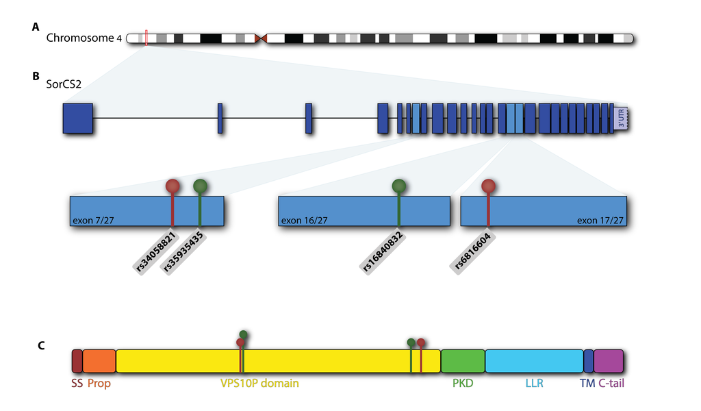

### Joseph’s Content

ADSP data was processed using the Genome GPS pipeline by the Bioinformatics Core in Rochestor. After variant calling (using ‘GenotypeGVCFs’ in the GATK pipeline), variants were annotated using BioR.  
Variants from genes of interest (here, SORCS2) were identified and processed using Perl scripts to generate files for downstream analysis.

```r
system("perl generate_flat_file_SG.pl ADSP ADSP_sample_sex_age_AD_APOE.txt SORCS2_variants.txt 1000 SORCS2_ff.txt SORCS2_allele_counts.txt")

#Sex : 0: Male, 1: Female
#Case/Control: 0: Control, 1: AD, 2: Probable AD
#Call: 11/12/22
#Genotype: 0/0, 0/1, 1/1,  [./., ./0, ./1, 0/., 1/. encoded as NA]

#Importing Flat File
SORCS2_FF <- read.table("SORCS2_ff.txt",header = TRUE, check.names = FALSE)
head(SORCS2_FF)
```

```
##   Subject_ID Series Sex      Age Case/control APOE   Gene      SNP_ID  CHR
## 1 SRR1198015   ADSP   0 64.00000            2   34 SORCS2 rs527549780 chr4
## 2 SRR1198016   ADSP   0 71.00000            2   34 SORCS2 rs527549780 chr4
## 3 SRR1267825   ADSP   1 84.98015            1   23 SORCS2 rs527549780 chr4
## 4 SRR1267826   ADSP   0 87.29911            1   33 SORCS2 rs527549780 chr4
## 5 SRR1267827   ADSP   0 82.17659            1   33 SORCS2 rs527549780 chr4
## 6 SRR1267828   ADSP   0 90.81999            1   33 SORCS2 rs527549780 chr4
##   Position Ref Alt   Codon    AA Call Genotype
## 1  7640109   G   A Gca/Aca A235T   11      0/0
## 2  7640109   G   A Gca/Aca A235T   11      0/0
## 3  7640109   G   A Gca/Aca A235T   11      0/0
## 4  7640109   G   A Gca/Aca A235T   11      0/0
## 5  7640109   G   A Gca/Aca A235T   11      0/0
## 6  7640109   G   A Gca/Aca A235T   11      0/0
```

```r
#Importing allele counts for each variant
SORCS2_variants <- read.table("SORCS2_allele_counts.txt", header = TRUE, check.names = FALSE)
head(SORCS2_variants)
```

```
##     Gene      SNP_ID  Chr Position Ref Alt   Codon    AA Control(0/0)
## 1 SORCS2 rs527549780 chr4  7640109   G   A Gca/Aca A235T          499
## 2 SORCS2           . chr4  7666086   G   A cGg/cAg R148Q          499
## 3 SORCS2  rs34058821 chr4  7666160   G   A Ggg/Agg G173R          456
## 4 SORCS2  rs35935435 chr4  7666180   C   A gaC/gaA D179E          474
## 5 SORCS2  rs77455588 chr4  7668881   G   A Gtc/Atc V196I          500
## 6 SORCS2           . chr4  7677883   G   A cGc/cAc R251H          499
##   Control(0/1) Control(1/1) Control(NA) AD(0/0) AD(0/1) AD(1/1) AD(NA)
## 1            0            0           1     499       1       0      0
## 2            1            0           0     500       0       0      0
## 3           43            1           0     462      37       1      0
## 4           26            0           0     473      27       0      0
## 5            0            0           0     499       1       0      0
## 6            1            0           0     500       0       0      0
```